#### Virtualisation et Cloud - © TEK-UP University

# LAB06 : Conteneurisation d’une pile LAMP (Linux Apache – PHP – MySQL)

# avec Docker Compose

### Objectifs

- Ce TP a pour objectif de vous familiariser avec le déploiement d’applications Docker multi-conteneurs.
- Deux approches seront abordées :
  - Déploiement d’une pile LAMP avec Docker, en gérant chaque conteneur individuellement.
  - Déploiement d’une pile LAMP avec Docker Compose, en orchestrant plusieurs conteneurs de manière simplifiée et automatisée.

# 1. Description de l'application

- On considère une application web de gestion des articles scientifiques qui permet d'ajouter les nouveaux articles à une base de données.

## 1.1. Interface frontend de l’application

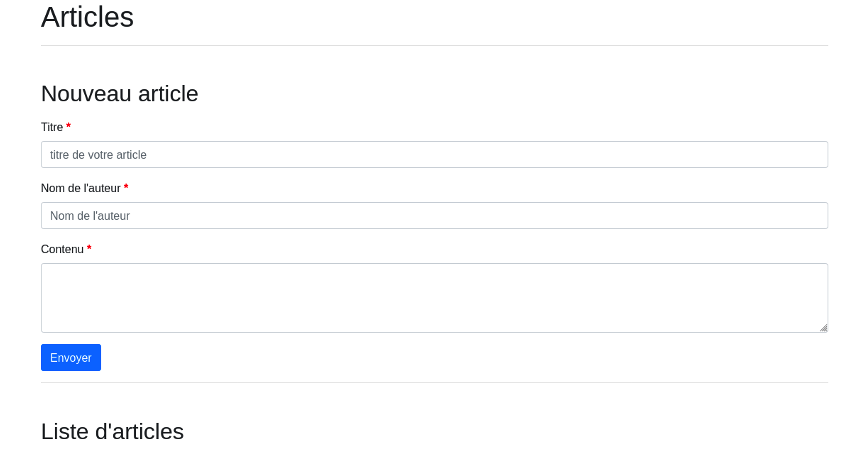

# 1.2. Architecture conteneurisée

[figure not shown]

### 1.2.1. Le serveur web (conteneur Apache/PHP)

- Ce conteneur héberge le code PHP de l’application.
- Lorsqu’un utilisateur soumet un article, le serveur web récupère les champs du formulaire, vérifie les données, puis dialogue avec MySQL pour enregistrer l’article.
- Le serveur web s’appuie sur un fichier de configuration (**db-config.php**) qui décrit comment se connecter au serveur MySQL via le réseau Docker (nom d’hôte, utilisateur, mot de passe, etc.).

### 1.2.3. Le volume partagé

- Le volume **db-volume** est monté dans le conteneur MySQL et assure la persistance des données entre les redémarrages.

## 1.3. Structure du projet

- La structure du projet rassemble l’ensemble des fichiers nécessaires au fonctionnement de l’application. Le dossier **sources** , fourni avec ce lab, contient à la fois les sources PHP et les fichiers d’initialisation de la base de données. Il est organisé comme suit :

```
sources/
│
├── articles.sql
│
└── app/
    ├── db-config.php
    ├── index.php
    └── validation.php
```

- **articles.sql :** Ce fichier contient le script SQL chargé d’initialiser la base de données. Lors du premier démarrage du conteneur MySQL, il crée la table des articles et prépare l’environnement pour que l’application puisse enregistrer de nouvelles entrées.
- **app/** Ce répertoire regroupe l’ensemble du code source PHP exécuté dans le conteneur Apache.
  - **db-config.php :** fichier de configuration de la connexion MySQL. Il définit les paramètres nécessaires pour que PHP puisse contacter le serveur de base de données (hôte, nom de base, utilisateur, mot de passe). Le serveur web s’appuie sur ce fichier pour dialoguer avec MySQL dans l’environnement Docker.
  - **index.php :** Page principale de l’application. Elle affiche le formulaire de création d’un article et la liste des articles déjà enregistrés dans la base. C’est la porte d’entrée de l’interface web.
  - **validation.php :** Script chargé de traiter les données soumises via le formulaire. Il valide la présence des champs obligatoires, puis enregistre le nouvel article dans la base à l’aide des paramètres définis dans db-config.php. Une fois l’insertion faite, il renvoie l’utilisateur vers la page principale.

# 2. Application Docker multi-conteneurs

## 2.1. Préparation de l'application web Docker

### Étape 1 : image de base

- On va utiliser l'image officielle Docker "**php:7-apache**" : Image qui contient apache httpd avec php
- Visitez le lien : https://hub.docker.com/_/php
- Lisez la description de la variante image de type : **php:version-apache**

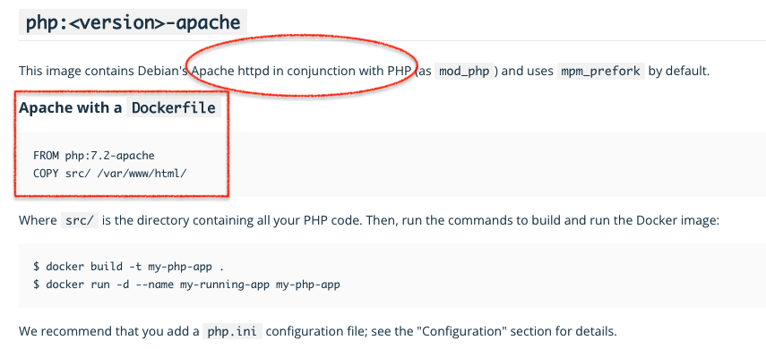

### Étape 2 : Configuration

- Le code source de l'application web est fourni avec le TP: dossier "app".
- Le code php de l'application sera copié sur le système de fichiers de l'image à la destination "/var/www/html" : **on va copier ce code lors de la création du Dockerfile**

### Étape 3 : Fichier Dockerfile

1. Placez vous dans le répertoire **"sources"** et créez le fichier Dockerfile

```python
cd sources
nano dockerfile
```

- Contenu du fichier Dockerfile

```python
FROM php:7-apache
# Activation des modules php
RUN docker-php-ext-install pdo pdo_mysql
# Configuration
WORKDIR  /var/www/html
COPY app/ .
```

### Étape 4 : Création image

2. Créez l'image docker "myweb_app" de votre application web.

```python
docker build -t myweb_app .
```

3. Vérifiez la création de l’image "myweb_app"

```python
docker images
```

```python
# OUTPUT

REPOSITORY   TAG                IMAGE ID       CREATED         SIZE
myweb_app        latest             5869c8052678   4 minutes ago   469MB
php          7-apache           c6d45f57dd6d   2 weeks ago     469MB
```

## 2.2. Préparation de l'application MySQL Docker

### Étape 1 : image de base

- On va utiliser une image docker **"mysql:5.7"**
- Visitez le lien : https://hub.docker.com/_/mysql
- Lisez la description de l'image : mysql

### Étape 2 : Configuration

- Lors de la création de l'image, il faut configurer les paramètres d'environnement suivant :
  - **MYSQL_ROOT_PASSWORD='test'**
  - **MYSQL_DATABASE='test'**
  - **MYSQL_USER='test'**
  - **MYSQL_PASSWORD='test'**
- Il faut également importer le fichier base de données **"article.sql"**
- Les variables d'environnement seront ajoutés lors de la création du Dockerfile avec l'instruction **ENV** :

ENV MYSQL_DATABASE=test  
ENV MYSQL_ROOT_PASSWORD=test  
ENV MYSQL_USER=test  
ENV MYSQL_PASSWORD=test

- Le script **article.sql** sera ajouté et éxécuté à l'intérieur du conteneur lors de son premier démarrage. Ce fichier sera intégré à l’image grâce à l’instruction **ADD**, qui permet d’ajouter un fichier à exécuter automatiquement par MySQL :

ADD articles.sql /docker-entrypoint-initdb.d

### Étape 3 : Edition Dockerfile

1. Placez vous sur le répertoire "sources" et éditez de nouveau le fichier Dockerfile.

```python
nano dockerfile
```

- Contenu modifié du fichier Dockerfile

```python
FROM mysql:5.7

ENV MYSQL_DATABASE=test
ENV MYSQL_ROOT_PASSWORD=test
ENV MYSQL_USER=test
ENV MYSQL_PASSWORD=test
### import sql table
ADD articles.sql /docker-entrypoint-initdb.d
```

### Étape 4 : Création image

2. Créez l'image docker "mysql_db"

```python
docker build -t mysql_db .
```

3. Vérifiez la création de l’image mysql_db

```python
docker images
```

```python
# Résultat
REPOSITORY   TAG                IMAGE ID       CREATED          SIZE
mysql_db     latest             e9b6821c88d7   6 seconds ago    448MB
myweb_app     latest             5869c8052678   31 minutes ago   469MB
php          7-apache           c6d45f57dd6d   2 weeks ago      469MB
mysql        5.7                938b57d64674   2 weeks ago      448MB
```